# Risk Factor Analysis

## Outcome Variable

**Outcome Variable:** wasted

## Predictor Variables

**Intervention Variable:** meducyrs

**Adjustment Set:**

- arm
- W_mage
- feducyrs
- W_mhtcm
- W_gagebrth
- W_birthwt
- W_birthlen
- single
- impsan
- delta_W_mage
- delta_feducyrs
- delta_W_mhtcm
- delta_W_gagebrth
- delta_W_birthwt
- delta_W_birthlen
- delta_single
- delta_impsan

## Stratifying Variables

The analysis was stratified on these variable(s):

- agecat
- studyid
- country

## Data Summary

| agecat | studyid | country | meducyrs | wasted | n_cell | n |
| --- | --- | --- | --- | --- | --- | --- |
| Birth | ki0047075b-MAL-ED | BANGLADESH | High | 0 | 63 | 195 |
| Birth | ki0047075b-MAL-ED | BANGLADESH | High | 1 | 9 | 195 |
| Birth | ki0047075b-MAL-ED | BANGLADESH | Low | 0 | 54 | 195 |
| Birth | ki0047075b-MAL-ED | BANGLADESH | Low | 1 | 9 | 195 |
| Birth | ki0047075b-MAL-ED | BANGLADESH | Medium | 0 | 45 | 195 |
| Birth | ki0047075b-MAL-ED | BANGLADESH | Medium | 1 | 15 | 195 |
| Birth | ki0047075b-MAL-ED | BRAZIL | High | 0 | 63 | 182 |
| Birth | ki0047075b-MAL-ED | BRAZIL | High | 1 | 0 | 182 |
| Birth | ki0047075b-MAL-ED | BRAZIL | Low | 0 | 48 | 182 |
| Birth | ki0047075b-MAL-ED | BRAZIL | Low | 1 | 3 | 182 |
| Birth | ki0047075b-MAL-ED | BRAZIL | Medium | 0 | 65 | 182 |
| Birth | ki0047075b-MAL-ED | BRAZIL | Medium | 1 | 3 | 182 |
| Birth | ki0047075b-MAL-ED | INDIA | High | 0 | 47 | 180 |
| Birth | ki0047075b-MAL-ED | INDIA | High | 1 | 4 | 180 |
| Birth | ki0047075b-MAL-ED | INDIA | Low | 0 | 48 | 180 |
| Birth | ki0047075b-MAL-ED | INDIA | Low | 1 | 12 | 180 |
| Birth | ki0047075b-MAL-ED | INDIA | Medium | 0 | 55 | 180 |
| Birth | ki0047075b-MAL-ED | INDIA | Medium | 1 | 14 | 180 |
| Birth | ki0047075b-MAL-ED | NEPAL | High | 0 | 30 | 155 |
| Birth | ki0047075b-MAL-ED | NEPAL | High | 1 | 7 | 155 |
| Birth | ki0047075b-MAL-ED | NEPAL | Low | 0 | 61 | 155 |
| Birth | ki0047075b-MAL-ED | NEPAL | Low | 1 | 4 | 155 |
| Birth | ki0047075b-MAL-ED | NEPAL | Medium | 0 | 45 | 155 |
| Birth | ki0047075b-MAL-ED | NEPAL | Medium | 1 | 8 | 155 |
| Birth | ki0047075b-MAL-ED | PERU | High | 0 | 80 | 278 |
| Birth | ki0047075b-MAL-ED | PERU | High | 1 | 2 | 278 |
| Birth | ki0047075b-MAL-ED | PERU | Low | 0 | 98 | 278 |
| Birth | ki0047075b-MAL-ED | PERU | Low | 1 | 0 | 278 |
| Birth | ki0047075b-MAL-ED | PERU | Medium | 0 | 94 | 278 |
| Birth | ki0047075b-MAL-ED | PERU | Medium | 1 | 4 | 278 |

[output cut: 378 more lines]

The following strata were considered:

- agecat: 24 months, studyid: ki0047075b-MAL-ED, country: BANGLADESH
- agecat: 24 months, studyid: ki0047075b-MAL-ED, country: BRAZIL
- agecat: 24 months, studyid: ki0047075b-MAL-ED, country: INDIA
- agecat: 24 months, studyid: ki0047075b-MAL-ED, country: NEPAL
- agecat: 24 months, studyid: ki0047075b-MAL-ED, country: PERU
- agecat: 24 months, studyid: ki0047075b-MAL-ED, country: SOUTH AFRICA
- agecat: 24 months, studyid: ki0047075b-MAL-ED, country: TANZANIA, UNITED REPUBLIC OF
- agecat: 24 months, studyid: ki1000108-CMC-V-BCS-2002, country: INDIA
- agecat: 24 months, studyid: ki1000108-IRC, country: INDIA
- agecat: 24 months, studyid: ki1017093-NIH-Birth, country: BANGLADESH
- agecat: 24 months, studyid: ki1017093b-PROVIDE, country: BANGLADESH
- agecat: 24 months, studyid: ki1017093c-NIH-Crypto, country: BANGLADESH
- agecat: 24 months, studyid: ki1066203-TanzaniaChild2, country: TANZANIA, UNITED REPUBLIC OF
- agecat: 24 months, studyid: ki1113344-GMS-Nepal, country: NEPAL
- agecat: 24 months, studyid: ki1119695-PROBIT, country: BELARUS
- agecat: 24 months, studyid: ki1126311-ZVITAMBO, country: ZIMBABWE
- agecat: 24 months, studyid: ki1135781-COHORTS, country: GUATEMALA
- agecat: 24 months, studyid: ki1135781-COHORTS, country: INDIA
- agecat: 24 months, studyid: ki1135781-COHORTS, country: PHILIPPINES
- agecat: 24 months, studyid: ki1148112-LCNI-5, country: MALAWI
- agecat: 24 months, studyid: kiGH5241-JiVitA-3, country: BANGLADESH
- agecat: 24 months, studyid: kiGH5241-JiVitA-4, country: BANGLADESH
- agecat: 6 months, studyid: ki0047075b-MAL-ED, country: BANGLADESH
- agecat: 6 months, studyid: ki0047075b-MAL-ED, country: BRAZIL
- agecat: 6 months, studyid: ki0047075b-MAL-ED, country: INDIA
- agecat: 6 months, studyid: ki0047075b-MAL-ED, country: NEPAL
- agecat: 6 months, studyid: ki0047075b-MAL-ED, country: PERU
- agecat: 6 months, studyid: ki0047075b-MAL-ED, country: SOUTH AFRICA
- agecat: 6 months, studyid: ki0047075b-MAL-ED, country: TANZANIA, UNITED REPUBLIC OF
- agecat: 6 months, studyid: ki1000108-CMC-V-BCS-2002, country: INDIA
- agecat: 6 months, studyid: ki1000108-IRC, country: INDIA
- agecat: 6 months, studyid: ki1000109-EE, country: PAKISTAN
- agecat: 6 months, studyid: ki1000304b-SAS-CompFeed, country: INDIA
- agecat: 6 months, studyid: ki1000304b-SAS-FoodSuppl, country: INDIA
- agecat: 6 months, studyid: ki1017093-NIH-Birth, country: BANGLADESH
- agecat: 6 months, studyid: ki1017093b-PROVIDE, country: BANGLADESH
- agecat: 6 months, studyid: ki1017093c-NIH-Crypto, country: BANGLADESH
- agecat: 6 months, studyid: ki1066203-TanzaniaChild2, country: TANZANIA, UNITED REPUBLIC OF
- agecat: 6 months, studyid: ki1112895-Guatemala BSC, country: GUATEMALA
- agecat: 6 months, studyid: ki1113344-GMS-Nepal, country: NEPAL
- agecat: 6 months, studyid: ki1119695-PROBIT, country: BELARUS
- agecat: 6 months, studyid: ki1126311-ZVITAMBO, country: ZIMBABWE
- agecat: 6 months, studyid: ki1135781-COHORTS, country: GUATEMALA
- agecat: 6 months, studyid: ki1135781-COHORTS, country: INDIA
- agecat: 6 months, studyid: ki1135781-COHORTS, country: PHILIPPINES
- agecat: 6 months, studyid: ki1148112-LCNI-5, country: MALAWI
- agecat: 6 months, studyid: kiGH5241-JiVitA-3, country: BANGLADESH
- agecat: 6 months, studyid: kiGH5241-JiVitA-4, country: BANGLADESH
- agecat: Birth, studyid: ki0047075b-MAL-ED, country: BANGLADESH
- agecat: Birth, studyid: ki0047075b-MAL-ED, country: BRAZIL
- agecat: Birth, studyid: ki0047075b-MAL-ED, country: INDIA
- agecat: Birth, studyid: ki0047075b-MAL-ED, country: NEPAL
- agecat: Birth, studyid: ki0047075b-MAL-ED, country: PERU
- agecat: Birth, studyid: ki0047075b-MAL-ED, country: SOUTH AFRICA
- agecat: Birth, studyid: ki0047075b-MAL-ED, country: TANZANIA, UNITED REPUBLIC OF
- agecat: Birth, studyid: ki1000108-CMC-V-BCS-2002, country: INDIA
- agecat: Birth, studyid: ki1000108-IRC, country: INDIA
- agecat: Birth, studyid: ki1000109-EE, country: PAKISTAN
- agecat: Birth, studyid: ki1000304b-SAS-CompFeed, country: INDIA
- agecat: Birth, studyid: ki1017093-NIH-Birth, country: BANGLADESH
- agecat: Birth, studyid: ki1017093c-NIH-Crypto, country: BANGLADESH
- agecat: Birth, studyid: ki1119695-PROBIT, country: BELARUS
- agecat: Birth, studyid: ki1126311-ZVITAMBO, country: ZIMBABWE
- agecat: Birth, studyid: ki1135781-COHORTS, country: GUATEMALA
- agecat: Birth, studyid: ki1135781-COHORTS, country: INDIA
- agecat: Birth, studyid: ki1135781-COHORTS, country: PHILIPPINES
- agecat: Birth, studyid: kiGH5241-JiVitA-3, country: BANGLADESH
- agecat: Birth, studyid: kiGH5241-JiVitA-4, country: BANGLADESH

### Dropped Strata

Some strata were dropped due to rare outcomes:

- agecat: Birth, studyid: ki0047075b-MAL-ED, country: BRAZIL
- agecat: Birth, studyid: ki0047075b-MAL-ED, country: INDIA
- agecat: Birth, studyid: ki0047075b-MAL-ED, country: NEPAL
- agecat: Birth, studyid: ki0047075b-MAL-ED, country: PERU
- agecat: Birth, studyid: ki0047075b-MAL-ED, country: SOUTH AFRICA
- agecat: Birth, studyid: ki0047075b-MAL-ED, country: TANZANIA, UNITED REPUBLIC OF
- agecat: Birth, studyid: ki1000108-CMC-V-BCS-2002, country: INDIA
- agecat: Birth, studyid: ki1000109-EE, country: PAKISTAN
- agecat: Birth, studyid: ki1000304b-SAS-CompFeed, country: INDIA
- agecat: Birth, studyid: ki1017093-NIH-Birth, country: BANGLADESH
- agecat: Birth, studyid: ki1017093c-NIH-Crypto, country: BANGLADESH
- agecat: Birth, studyid: kiGH5241-JiVitA-4, country: BANGLADESH
- agecat: 6 months, studyid: ki0047075b-MAL-ED, country: BANGLADESH
- agecat: 6 months, studyid: ki0047075b-MAL-ED, country: BRAZIL
- agecat: 6 months, studyid: ki0047075b-MAL-ED, country: NEPAL
- agecat: 6 months, studyid: ki0047075b-MAL-ED, country: PERU
- agecat: 6 months, studyid: ki0047075b-MAL-ED, country: SOUTH AFRICA
- agecat: 6 months, studyid: ki0047075b-MAL-ED, country: TANZANIA, UNITED REPUBLIC OF
- agecat: 6 months, studyid: ki1000109-EE, country: PAKISTAN
- agecat: 6 months, studyid: ki1000304b-SAS-FoodSuppl, country: INDIA
- agecat: 6 months, studyid: ki1017093c-NIH-Crypto, country: BANGLADESH
- agecat: 6 months, studyid: ki1066203-TanzaniaChild2, country: TANZANIA, UNITED REPUBLIC OF
- agecat: 6 months, studyid: ki1112895-Guatemala BSC, country: GUATEMALA
- agecat: 6 months, studyid: ki1113344-GMS-Nepal, country: NEPAL
- agecat: 6 months, studyid: ki1148112-LCNI-5, country: MALAWI
- agecat: 6 months, studyid: kiGH5241-JiVitA-4, country: BANGLADESH
- agecat: 24 months, studyid: ki0047075b-MAL-ED, country: BANGLADESH
- agecat: 24 months, studyid: ki0047075b-MAL-ED, country: BRAZIL
- agecat: 24 months, studyid: ki0047075b-MAL-ED, country: INDIA
- agecat: 24 months, studyid: ki0047075b-MAL-ED, country: NEPAL
- agecat: 24 months, studyid: ki0047075b-MAL-ED, country: PERU
- agecat: 24 months, studyid: ki0047075b-MAL-ED, country: SOUTH AFRICA
- agecat: 24 months, studyid: ki0047075b-MAL-ED, country: TANZANIA, UNITED REPUBLIC OF
- agecat: 24 months, studyid: ki1066203-TanzaniaChild2, country: TANZANIA, UNITED REPUBLIC OF
- agecat: 24 months, studyid: ki1148112-LCNI-5, country: MALAWI

## Methods Detail

We’re interested in the causal parameters $E[Y_a]$ for all values of $a \in \mathcal{A}$. These parameters represent the mean outcome if, possibly contrary to fact, we intervened to set all units to have $A=a$. Under the randomization and positivity assumptions, these are identified by the statistical parameters $\psi_a=E_W[E_{Y|A,W}(Y|A=a,W)]$. In addition, we’re interested in the mean of $Y$, $E[Y]$ under no intervention (the observed mean). We will estimate these parameters by using SuperLearner to fit the relevant likelihood factors – $E_{Y|A,W}(Y|A=a,W)$ and $p(A=a|W)$, and then updating our likelihood fit using a joint TMLE.

For unadjusted analyses ($W=\{\}$), initial likelihoods were estimated using Lrnr_glm to estimate the simple $E(Y|A)$ and Lrnr_mean to estimate $p(A)$. For adjusted analyses, a small library containing Lrnr_glmnet, Lrnr_xgboost, and Lrnr_mean was used.

Having estimated these parameters, we will then use the delta method to estimate relative risks and attributable risks relative to a prespecified baseline level of $A$.

# Results Detail

## Results Plots

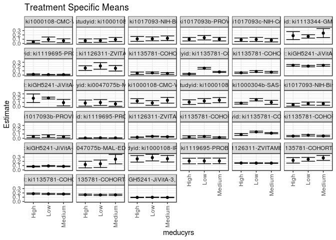

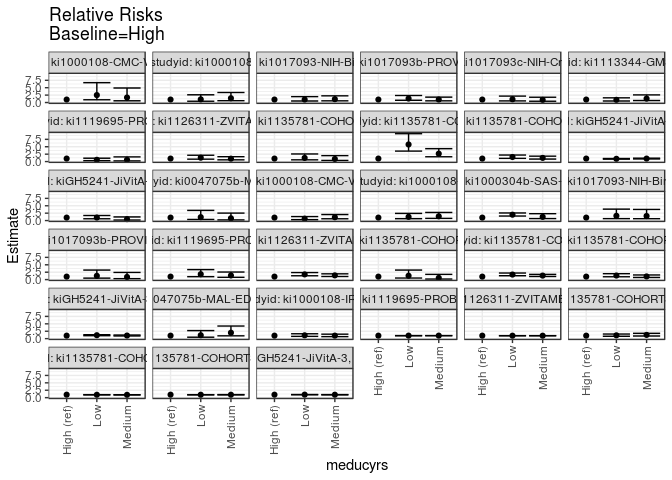

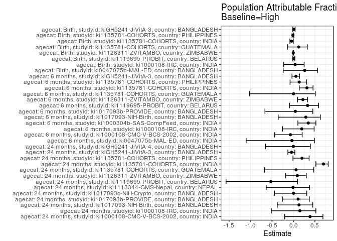

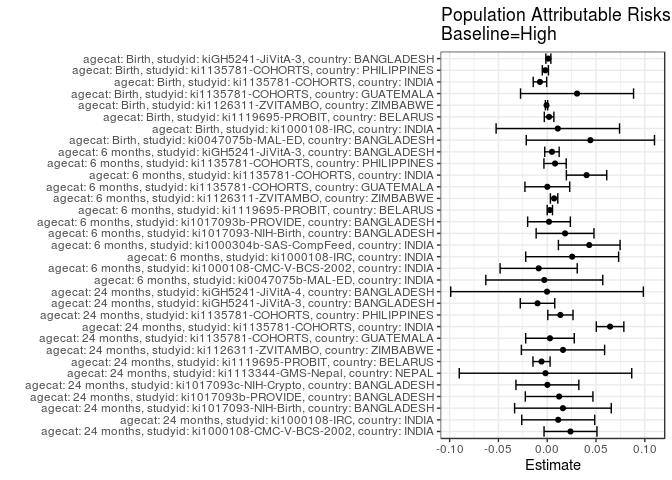

## Results Table

### Parameter: TSM

| agecat | studyid | country | intervention_level | baseline_level | estimate | ci_lower | ci_upper |
| --- | --- | --- | --- | --- | --- | --- | --- |
| Birth | ki0047075b-MAL-ED | BANGLADESH | High | NA | 0.1250000 | 0.0484126 | 0.2015874 |
| Birth | ki0047075b-MAL-ED | BANGLADESH | Low | NA | 0.1428571 | 0.0562264 | 0.2294878 |
| Birth | ki0047075b-MAL-ED | BANGLADESH | Medium | NA | 0.2500000 | 0.1401527 | 0.3598473 |
| Birth | ki1000108-IRC | INDIA | High | NA | 0.2573498 | 0.1805436 | 0.3341560 |
| Birth | ki1000108-IRC | INDIA | Low | NA | 0.2869781 | 0.2102231 | 0.3637331 |
| Birth | ki1000108-IRC | INDIA | Medium | NA | 0.2598191 | 0.1829053 | 0.3367329 |
| Birth | ki1119695-PROBIT | BELARUS | High | NA | 0.2069936 | 0.1415012 | 0.2724859 |
| Birth | ki1119695-PROBIT | BELARUS | Low | NA | 0.2090404 | 0.1435578 | 0.2745229 |
| Birth | ki1119695-PROBIT | BELARUS | Medium | NA | 0.2093662 | 0.1439927 | 0.2747397 |
| Birth | ki1126311-ZVITAMBO | ZIMBABWE | High | NA | 0.1601258 | 0.1536791 | 0.1665726 |
| Birth | ki1126311-ZVITAMBO | ZIMBABWE | Low | NA | 0.1583631 | 0.1513873 | 0.1653390 |
| Birth | ki1126311-ZVITAMBO | ZIMBABWE | Medium | NA | 0.1578338 | 0.1511904 | 0.1644773 |
| Birth | ki1135781-COHORTS | GUATEMALA | High | NA | 0.2220993 | 0.1581276 | 0.2860709 |
| Birth | ki1135781-COHORTS | GUATEMALA | Low | NA | 0.2473918 | 0.2026727 | 0.2921110 |
| Birth | ki1135781-COHORTS | GUATEMALA | Medium | NA | 0.2796949 | 0.2218795 | 0.3375102 |
| Birth | ki1135781-COHORTS | INDIA | High | NA | 0.1824844 | 0.1695763 | 0.1953925 |
| Birth | ki1135781-COHORTS | INDIA | Low | NA | 0.1776264 | 0.1659273 | 0.1893254 |
| Birth | ki1135781-COHORTS | INDIA | Medium | NA | 0.1737367 | 0.1629248 | 0.1845487 |
| Birth | ki1135781-COHORTS | PHILIPPINES | High | NA | 0.1574572 | 0.1438914 | 0.1710230 |
| Birth | ki1135781-COHORTS | PHILIPPINES | Low | NA | 0.1538470 | 0.1398106 | 0.1678834 |
| Birth | ki1135781-COHORTS | PHILIPPINES | Medium | NA | 0.1553477 | 0.1405593 | 0.1701362 |
| Birth | kiGH5241-JiVitA-3 | BANGLADESH | High | NA | 0.0948408 | 0.0891255 | 0.1005562 |
| Birth | kiGH5241-JiVitA-3 | BANGLADESH | Low | NA | 0.0967557 | 0.0911897 | 0.1023217 |
| Birth | kiGH5241-JiVitA-3 | BANGLADESH | Medium | NA | 0.0940427 | 0.0882613 | 0.0998241 |
| 6 months | ki0047075b-MAL-ED | INDIA | High | NA | 0.0847458 | 0.0135099 | 0.1559816 |
| 6 months | ki0047075b-MAL-ED | INDIA | Low | NA | 0.0972222 | 0.0286258 | 0.1658187 |
| 6 months | ki0047075b-MAL-ED | INDIA | Medium | NA | 0.0649351 | 0.0097642 | 0.1201059 |
| 6 months | ki1000108-CMC-V-BCS-2002 | INDIA | High | NA | 0.1337580 | 0.0804406 | 0.1870753 |
| 6 months | ki1000108-CMC-V-BCS-2002 | INDIA | Low | NA | 0.0865385 | 0.0324291 | 0.1406478 |
| 6 months | ki1000108-CMC-V-BCS-2002 | INDIA | Medium | NA | 0.1495327 | 0.0818708 | 0.2171946 |

[output cut: 69 more lines]

### Parameter: E(Y)

| agecat | studyid | country | intervention_level | baseline_level | estimate | ci_lower | ci_upper |
| --- | --- | --- | --- | --- | --- | --- | --- |
| Birth | ki0047075b-MAL-ED | BANGLADESH | NA | NA | 0.1692308 | 0.1164681 | 0.2219935 |
| Birth | ki1000108-IRC | INDIA | NA | NA | 0.2682216 | 0.2212677 | 0.3151755 |
| Birth | ki1119695-PROBIT | BELARUS | NA | NA | 0.2089120 | 0.1435514 | 0.2742726 |
| Birth | ki1126311-ZVITAMBO | ZIMBABWE | NA | NA | 0.1594293 | 0.1531109 | 0.1657477 |
| Birth | ki1135781-COHORTS | GUATEMALA | NA | NA | 0.2526738 | 0.2215120 | 0.2838356 |
| Birth | ki1135781-COHORTS | INDIA | NA | NA | 0.1750359 | 0.1643722 | 0.1856996 |
| Birth | ki1135781-COHORTS | PHILIPPINES | NA | NA | 0.1555709 | 0.1423748 | 0.1687670 |
| Birth | kiGH5241-JiVitA-3 | BANGLADESH | NA | NA | 0.0960153 | 0.0908094 | 0.1012212 |
| 6 months | ki0047075b-MAL-ED | INDIA | NA | NA | 0.0817308 | 0.0444108 | 0.1190507 |
| 6 months | ki1000108-CMC-V-BCS-2002 | INDIA | NA | NA | 0.1250000 | 0.0911644 | 0.1588356 |
| 6 months | ki1000108-IRC | INDIA | NA | NA | 0.1323529 | 0.0994307 | 0.1652752 |
| 6 months | ki1000304b-SAS-CompFeed | INDIA | NA | NA | 0.1244378 | 0.0992652 | 0.1496104 |
| 6 months | ki1017093-NIH-Birth | BANGLADESH | NA | NA | 0.0634328 | 0.0427791 | 0.0840865 |
| 6 months | ki1017093b-PROVIDE | BANGLADESH | NA | NA | 0.0412371 | 0.0250690 | 0.0574052 |
| 6 months | ki1119695-PROBIT | BELARUS | NA | NA | 0.0082503 | 0.0066012 | 0.0098994 |
| 6 months | ki1126311-ZVITAMBO | ZIMBABWE | NA | NA | 0.0321173 | 0.0283128 | 0.0359219 |
| 6 months | ki1135781-COHORTS | GUATEMALA | NA | NA | 0.0325289 | 0.0212599 | 0.0437978 |
| 6 months | ki1135781-COHORTS | INDIA | NA | NA | 0.1283521 | 0.1194359 | 0.1372684 |
| 6 months | ki1135781-COHORTS | PHILIPPINES | NA | NA | 0.0594974 | 0.0505830 | 0.0684118 |
| 6 months | kiGH5241-JiVitA-3 | BANGLADESH | NA | NA | 0.0846305 | 0.0798233 | 0.0894378 |
| 24 months | ki1000108-CMC-V-BCS-2002 | INDIA | NA | NA | 0.0618280 | 0.0373207 | 0.0863352 |
| 24 months | ki1000108-IRC | INDIA | NA | NA | 0.0757946 | 0.0501131 | 0.1014762 |
| 24 months | ki1017093-NIH-Birth | BANGLADESH | NA | NA | 0.1238318 | 0.0925894 | 0.1550741 |
| 24 months | ki1017093b-PROVIDE | BANGLADESH | NA | NA | 0.1124567 | 0.0866788 | 0.1382347 |
| 24 months | ki1017093c-NIH-Crypto | BANGLADESH | NA | NA | 0.0875486 | 0.0630907 | 0.1120065 |
| 24 months | ki1113344-GMS-Nepal | NEPAL | NA | NA | 0.1818182 | 0.1478065 | 0.2158299 |
| 24 months | ki1119695-PROBIT | BELARUS | NA | NA | 0.0110803 | 0.0050506 | 0.0171100 |
| 24 months | ki1126311-ZVITAMBO | ZIMBABWE | NA | NA | 0.1796690 | 0.1430402 | 0.2162979 |
| 24 months | ki1135781-COHORTS | GUATEMALA | NA | NA | 0.0458801 | 0.0333262 | 0.0584341 |
| 24 months | ki1135781-COHORTS | INDIA | NA | NA | 0.0921747 | 0.0833896 | 0.1009599 |
| 24 months | ki1135781-COHORTS | PHILIPPINES | NA | NA | 0.0681911 | 0.0582056 | 0.0781766 |
| 24 months | kiGH5241-JiVitA-3 | BANGLADESH | NA | NA | 0.2181099 | 0.2082292 | 0.2279905 |
| 24 months | kiGH5241-JiVitA-4 | BANGLADESH | NA | NA | 0.1970000 | 0.1761171 | 0.2178829 |

### Parameter: RR

| agecat | studyid | country | intervention_level | baseline_level | estimate | ci_lower | ci_upper |
| --- | --- | --- | --- | --- | --- | --- | --- |
| Birth | ki0047075b-MAL-ED | BANGLADESH | High | High | 1.0000000 | 1.0000000 | 1.000000 |
| Birth | ki0047075b-MAL-ED | BANGLADESH | Low | High | 1.1428571 | 0.4826209 | 2.706312 |
| Birth | ki0047075b-MAL-ED | BANGLADESH | Medium | High | 2.0000000 | 0.9409946 | 4.250821 |
| Birth | ki1000108-IRC | INDIA | High | High | 1.0000000 | 1.0000000 | 1.000000 |
| Birth | ki1000108-IRC | INDIA | Low | High | 1.1151283 | 0.7593837 | 1.637527 |
| Birth | ki1000108-IRC | INDIA | Medium | High | 1.0095949 | 0.6781507 | 1.503032 |
| Birth | ki1119695-PROBIT | BELARUS | High | High | 1.0000000 | 1.0000000 | 1.000000 |
| Birth | ki1119695-PROBIT | BELARUS | Low | High | 1.0098882 | 0.9812223 | 1.039392 |
| Birth | ki1119695-PROBIT | BELARUS | Medium | High | 1.0114623 | 0.9837810 | 1.039922 |
| Birth | ki1126311-ZVITAMBO | ZIMBABWE | High | High | 1.0000000 | 1.0000000 | 1.000000 |
| Birth | ki1126311-ZVITAMBO | ZIMBABWE | Low | High | 0.9889919 | 0.9662075 | 1.012314 |
| Birth | ki1126311-ZVITAMBO | ZIMBABWE | Medium | High | 0.9856863 | 0.9670623 | 1.004669 |
| Birth | ki1135781-COHORTS | GUATEMALA | High | High | 1.0000000 | 1.0000000 | 1.000000 |
| Birth | ki1135781-COHORTS | GUATEMALA | Low | High | 1.1138796 | 0.7965096 | 1.557706 |
| Birth | ki1135781-COHORTS | GUATEMALA | Medium | High | 1.2593236 | 0.8854623 | 1.791037 |
| Birth | ki1135781-COHORTS | INDIA | High | High | 1.0000000 | 1.0000000 | 1.000000 |
| Birth | ki1135781-COHORTS | INDIA | Low | High | 0.9733782 | 0.9244203 | 1.024929 |
| Birth | ki1135781-COHORTS | INDIA | Medium | High | 0.9520635 | 0.9103202 | 0.995721 |
| Birth | ki1135781-COHORTS | PHILIPPINES | High | High | 1.0000000 | 1.0000000 | 1.000000 |
| Birth | ki1135781-COHORTS | PHILIPPINES | Low | High | 0.9770718 | 0.9342447 | 1.021862 |
| Birth | ki1135781-COHORTS | PHILIPPINES | Medium | High | 0.9866030 | 0.9350895 | 1.040954 |
| Birth | kiGH5241-JiVitA-3 | BANGLADESH | High | High | 1.0000000 | 1.0000000 | 1.000000 |
| Birth | kiGH5241-JiVitA-3 | BANGLADESH | Low | High | 1.0201903 | 0.9814141 | 1.060499 |
| Birth | kiGH5241-JiVitA-3 | BANGLADESH | Medium | High | 0.9915847 | 0.9500213 | 1.034966 |
| 6 months | ki0047075b-MAL-ED | INDIA | High | High | 1.0000000 | 1.0000000 | 1.000000 |
| 6 months | ki0047075b-MAL-ED | INDIA | Low | High | 1.1472222 | 0.3828517 | 3.437673 |
| 6 months | ki0047075b-MAL-ED | INDIA | Medium | High | 0.7662338 | 0.2319005 | 2.531750 |
| 6 months | ki1000108-CMC-V-BCS-2002 | INDIA | High | High | 1.0000000 | 1.0000000 | 1.000000 |
| 6 months | ki1000108-CMC-V-BCS-2002 | INDIA | Low | High | 0.6469780 | 0.3082149 | 1.358080 |
| 6 months | ki1000108-CMC-V-BCS-2002 | INDIA | Medium | High | 1.1179350 | 0.6116839 | 2.043177 |

[output cut: 69 more lines]

### Parameter: PAR

| agecat | studyid | country | intervention_level | baseline_level | estimate | ci_lower | ci_upper |
| --- | --- | --- | --- | --- | --- | --- | --- |
| Birth | ki0047075b-MAL-ED | BANGLADESH | High | NA | 0.0442308 | -0.0214807 | 0.1099422 |
| Birth | ki1000108-IRC | INDIA | High | NA | 0.0108717 | -0.0523704 | 0.0741138 |
| Birth | ki1119695-PROBIT | BELARUS | High | NA | 0.0019185 | -0.0029827 | 0.0068197 |
| Birth | ki1126311-ZVITAMBO | ZIMBABWE | High | NA | -0.0006966 | -0.0018679 | 0.0004748 |
| Birth | ki1135781-COHORTS | GUATEMALA | High | NA | 0.0305745 | -0.0273353 | 0.0884844 |
| Birth | ki1135781-COHORTS | INDIA | High | NA | -0.0074485 | -0.0143422 | -0.0005549 |
| Birth | ki1135781-COHORTS | PHILIPPINES | High | NA | -0.0018863 | -0.0050246 | 0.0012520 |
| Birth | kiGH5241-JiVitA-3 | BANGLADESH | High | NA | 0.0011745 | -0.0013978 | 0.0037468 |
| 6 months | ki0047075b-MAL-ED | INDIA | High | NA | -0.0030150 | -0.0629190 | 0.0568890 |
| 6 months | ki1000108-CMC-V-BCS-2002 | INDIA | High | NA | -0.0087580 | -0.0482800 | 0.0307641 |
| 6 months | ki1000108-IRC | INDIA | High | NA | 0.0255696 | -0.0220255 | 0.0731648 |
| 6 months | ki1000304b-SAS-CompFeed | INDIA | High | NA | 0.0430669 | 0.0114824 | 0.0746514 |
| 6 months | ki1017093-NIH-Birth | BANGLADESH | High | NA | 0.0182715 | -0.0113600 | 0.0479031 |
| 6 months | ki1017093b-PROVIDE | BANGLADESH | High | NA | 0.0018282 | -0.0200444 | 0.0237009 |
| 6 months | ki1119695-PROBIT | BELARUS | High | NA | 0.0027066 | -0.0000278 | 0.0054409 |
| 6 months | ki1126311-ZVITAMBO | ZIMBABWE | High | NA | 0.0070484 | 0.0032596 | 0.0108371 |
| 6 months | ki1135781-COHORTS | GUATEMALA | High | NA | 0.0000964 | -0.0228389 | 0.0230318 |
| 6 months | ki1135781-COHORTS | INDIA | High | NA | 0.0403149 | 0.0196397 | 0.0609901 |
| 6 months | ki1135781-COHORTS | PHILIPPINES | High | NA | 0.0080511 | -0.0033811 | 0.0194832 |
| 6 months | kiGH5241-JiVitA-3 | BANGLADESH | High | NA | 0.0048549 | -0.0025388 | 0.0122486 |
| 24 months | ki1000108-CMC-V-BCS-2002 | INDIA | High | NA | 0.0238533 | -0.0032516 | 0.0509582 |
| 24 months | ki1000108-IRC | INDIA | High | NA | 0.0112785 | -0.0261027 | 0.0486597 |
| 24 months | ki1017093-NIH-Birth | BANGLADESH | High | NA | 0.0160935 | -0.0334320 | 0.0656190 |
| 24 months | ki1017093b-PROVIDE | BANGLADESH | High | NA | 0.0121973 | -0.0224420 | 0.0468365 |
| 24 months | ki1017093c-NIH-Crypto | BANGLADESH | High | NA | 0.0001917 | -0.0320440 | 0.0324273 |
| 24 months | ki1113344-GMS-Nepal | NEPAL | High | NA | -0.0017649 | -0.0901319 | 0.0866021 |
| 24 months | ki1119695-PROBIT | BELARUS | High | NA | -0.0058347 | -0.0145995 | 0.0029302 |
| 24 months | ki1126311-ZVITAMBO | ZIMBABWE | High | NA | 0.0161789 | -0.0264625 | 0.0588203 |
| 24 months | ki1135781-COHORTS | GUATEMALA | High | NA | 0.0028179 | -0.0220618 | 0.0276977 |
| 24 months | ki1135781-COHORTS | INDIA | High | NA | 0.0644096 | 0.0502978 | 0.0785214 |
| 24 months | ki1135781-COHORTS | PHILIPPINES | High | NA | 0.0135268 | 0.0006232 | 0.0264304 |
| 24 months | kiGH5241-JiVitA-3 | BANGLADESH | High | NA | -0.0099344 | -0.0276086 | 0.0077398 |
| 24 months | kiGH5241-JiVitA-4 | BANGLADESH | High | NA | -0.0001831 | -0.0988763 | 0.0985101 |

### Parameter: PAF

| agecat | studyid | country | intervention_level | baseline_level | estimate | ci_lower | ci_upper |
| --- | --- | --- | --- | --- | --- | --- | --- |
| Birth | ki0047075b-MAL-ED | BANGLADESH | High | NA | 0.2613636 | -0.2393487 | 0.5597819 |
| Birth | ki1000108-IRC | INDIA | High | NA | 0.0405326 | -0.2264183 | 0.2493772 |
| Birth | ki1119695-PROBIT | BELARUS | High | NA | 0.0091831 | -0.0147060 | 0.0325098 |
| Birth | ki1126311-ZVITAMBO | ZIMBABWE | High | NA | -0.0043690 | -0.0117422 | 0.0029504 |
| Birth | ki1135781-COHORTS | GUATEMALA | High | NA | 0.1210040 | -0.1402225 | 0.3223832 |
| Birth | ki1135781-COHORTS | INDIA | High | NA | -0.0425544 | -0.0826819 | -0.0039142 |
| Birth | ki1135781-COHORTS | PHILIPPINES | High | NA | -0.0121251 | -0.0325262 | 0.0078729 |
| Birth | kiGH5241-JiVitA-3 | BANGLADESH | High | NA | 0.0122323 | -0.0149062 | 0.0386451 |
| 6 months | ki0047075b-MAL-ED | INDIA | High | NA | -0.0368893 | -1.1021076 | 0.4885421 |
| 6 months | ki1000108-CMC-V-BCS-2002 | INDIA | High | NA | -0.0700637 | -0.4373815 | 0.2033873 |
| 6 months | ki1000108-IRC | INDIA | High | NA | 0.1931928 | -0.2558248 | 0.4816651 |
| 6 months | ki1000304b-SAS-CompFeed | INDIA | High | NA | 0.3460916 | 0.1032165 | 0.5231890 |
| 6 months | ki1017093-NIH-Birth | BANGLADESH | High | NA | 0.2880455 | -0.3557125 | 0.6261160 |
| 6 months | ki1017093b-PROVIDE | BANGLADESH | High | NA | 0.0443350 | -0.6642877 | 0.4512393 |
| 6 months | ki1119695-PROBIT | BELARUS | High | NA | 0.3280548 | -0.0904913 | 0.5859570 |
| 6 months | ki1126311-ZVITAMBO | ZIMBABWE | High | NA | 0.2194564 | 0.0955143 | 0.3264147 |
| 6 months | ki1135781-COHORTS | GUATEMALA | High | NA | 0.0029643 | -1.0222350 | 0.5084250 |
| 6 months | ki1135781-COHORTS | INDIA | High | NA | 0.3140961 | 0.1345516 | 0.4563926 |
| 6 months | ki1135781-COHORTS | PHILIPPINES | High | NA | 0.1353178 | -0.0785425 | 0.3067725 |
| 6 months | kiGH5241-JiVitA-3 | BANGLADESH | High | NA | 0.0573658 | -0.0341516 | 0.1407844 |
| 24 months | ki1000108-CMC-V-BCS-2002 | INDIA | High | NA | 0.3858008 | -0.2035002 | 0.6865471 |
| 24 months | ki1000108-IRC | INDIA | High | NA | 0.1488033 | -0.5154091 | 0.5218877 |
| 24 months | ki1017093-NIH-Birth | BANGLADESH | High | NA | 0.1299623 | -0.3757739 | 0.4497893 |
| 24 months | ki1017093b-PROVIDE | BANGLADESH | High | NA | 0.1084617 | -0.2583942 | 0.3683692 |
| 24 months | ki1017093c-NIH-Crypto | BANGLADESH | High | NA | 0.0021894 | -0.4431495 | 0.3101020 |
| 24 months | ki1113344-GMS-Nepal | NEPAL | High | NA | -0.0097071 | -0.6340752 | 0.3760946 |
| 24 months | ki1119695-PROBIT | BELARUS | High | NA | -0.5265812 | -1.5703499 | 0.0933335 |
| 24 months | ki1126311-ZVITAMBO | ZIMBABWE | High | NA | 0.0900484 | -0.1808378 | 0.2987929 |
| 24 months | ki1135781-COHORTS | GUATEMALA | High | NA | 0.0614198 | -0.6721728 | 0.4731808 |
| 24 months | ki1135781-COHORTS | INDIA | High | NA | 0.6987770 | 0.5223257 | 0.8100478 |
| 24 months | ki1135781-COHORTS | PHILIPPINES | High | NA | 0.1983664 | -0.0119546 | 0.3649750 |
| 24 months | kiGH5241-JiVitA-3 | BANGLADESH | High | NA | -0.0455476 | -0.1298194 | 0.0324384 |
| 24 months | kiGH5241-JiVitA-4 | BANGLADESH | High | NA | -0.0009294 | -0.6511113 | 0.3932210 |